# MECH481A6: Engineering Data Analysis in R

Chapter 5 Homework: Exploring Univariate Data

Daniel Pelphrey

26 October, 2023

# Grading

We will grade the **knitted** PDF or HTML document from within your private GitHub repository. Remember to make regular, small commits (e.g., at least one commit per question) to save your work. We will grade the latest knit, as long as it occurs *before* the start of the class in which we advance to the next chapter. As always, reach out with questions via GitHub Issues or during office hours.

# Data

You are probably sick of seeing the ozone data, but there’s still more to do with the file. Ozone concentration measurement is considered univariate, thus we can use basic exploratory data analysis approaches to examine the data.

# Preparation

Load the necessary R packages into your R session.

Recreate the pipe of `dplyr` functions that you used to import the data, select and rename the variables listed below, drop missing observations, and assign the output with a good name.

- `sample_measurement` renamed as `ozone_ppm` (ozone measurement in ppm)
- `datetime` (date in YYYY-MM-DD format and time of measurement in HH:MM:SS)

Check that the data imported correctly.

```
## # A tibble: 20 × 2
##    ozone_ppm datetime
##        <dbl> <dttm>
##  1     0.017 2019-01-01 07:00:00
##  2     0.017 2019-01-01 08:00:00
##  3     0.017 2019-01-01 09:00:00
##  4     0.017 2019-01-01 10:00:00
##  5     0.015 2019-01-01 11:00:00
##  6     0.017 2019-01-01 12:00:00
##  7     0.028 2019-01-01 13:00:00
##  8     0.03  2019-01-01 14:00:00
##  9     0.036 2019-01-01 15:00:00
## 10     0.036 2019-01-01 16:00:00
## 11     0.033 2019-01-01 17:00:00
## 12     0.032 2019-01-01 18:00:00
## 13     0.031 2019-01-01 19:00:00
## 14     0.028 2019-01-01 20:00:00
## 15     0.027 2019-01-01 21:00:00
## 16     0.026 2019-01-01 22:00:00
## 17     0.023 2019-01-01 23:00:00
## 18     0.016 2019-01-02 00:00:00
## 19     0.016 2019-01-02 01:00:00
## 20     0.006 2019-01-02 02:00:00
```

# Chapter 5 Homework: Exploring Univariate Data

Through Question 5, you will use all of the available ozone measurements from January 2019 through January 2020. Starting in Question 6, you will use a subset of the dataset: ozone concentration measurements on July 4, 2019.

## Question 1: Definitions

Guess the location, dispersion, and shape of ozone concentration data, based on the definitions of each described in the coursebook. No code needed; just use your intuition. For shape, take a look at the coursebook appendix on reference distributions.

I would guess the data will have an oscillatory shape. I would assume that it varies with time of day and possible day of year as well.

## Question 2: Quartiles

Calculate the quartiles of `ozone_ppm`. What is the minimum? Maximum? Median?

```
##    0%   50%  100%
## 0.000 0.033 0.096
```

### Extra Credit

Create [a similar table](https://smogdr.github.io/edar_coursebook/eda1.html#descriptive-statistics) for `ozone_ppm`. Hint: You will need to investigate table options in the `knitr` package.

## Question 3: Cumulative Distribution Plot

Using either relevant `ggplot2` `geom` option, create a cumulative distribution plot of `ozone_ppm`. Tweak the axis ranges for optimal data representation, using `scale_*_continuous()` with `breaks =` and `minor_breaks =` arguments. Add axis labels, title, subtitle, and theme.

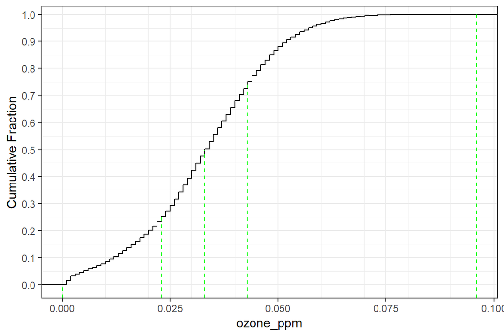

## Question 4: Histogram

Create a histogram of `ozone_ppm`. Within the `geom`, mess with the number of bins (e.g., 20, 50, 75, 100, 200) to explore the true shape and granularity of the data. Match the plot style (e.g., title, subtitle, axis labels, theme) you chose in Question 3, with the relevant adjustments such as “Histogram” instead of “Cumulative Distribution Plot”.

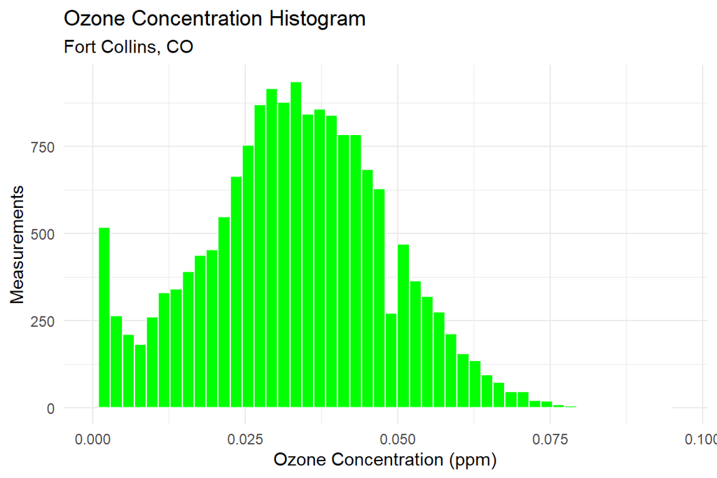

### Question 5: Concept

What mathematical concept is a histogram (Q4) attempting to visualize?

The histogram helps show the the probability of each value to show up in the data.

### Question 6: Distribution

Based on the histogram (Q4), does ozone concentration appear to be normally distributed?

### Question 7: Outliers

Based on the histogram (Q4), do you see any possible outliers? Skewness? How might this affect the spread and central tendency?

There were a few outliers on the high end of the ozone levels. There were also a lot of near zero input which I thought was odd.

## Question 8: Boxplot

Generate a boxplot of ozone concentration on the y-axis with a title, subtitle, y-axis label, and theme consistent with the style of the previous two plots. Use quotes (`""`) as the `x` arguments within the calls to the aesthetic and labels to remove the x-axis scale and label.

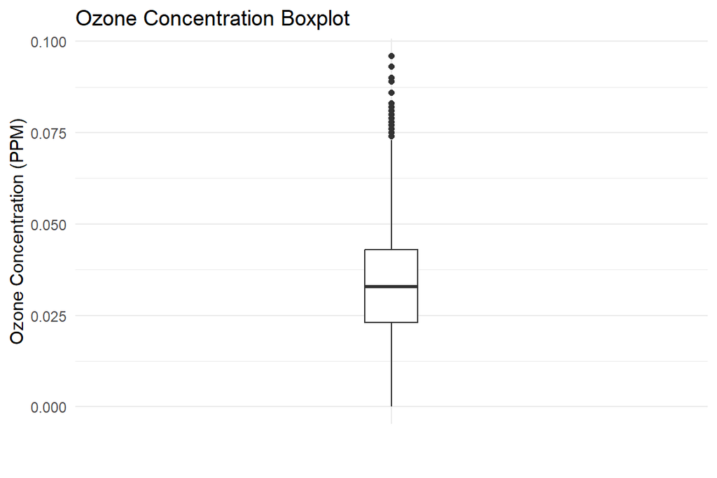

# Subset Data

Use the following code to create a dataframe for use in the remaining questions. These ozone concentration measurements were taken on July 4, 2019 in Fort Collins, CO. This code detects certain characters with the `datetime` object and filters to observations containing those characters. There are other ways this could have been done (e.g., `dplyr::filter()` with `%in%` operator).

## Question 9: Autocorrelation Plot

Define autocorrelation as it relates to ozone concentration measurement.

Create an autocorrelation plot of ozone concentration, using `stats::acf()` and include axis labels and title. Describe what you see based on the features of interest outlined in the coursebook.

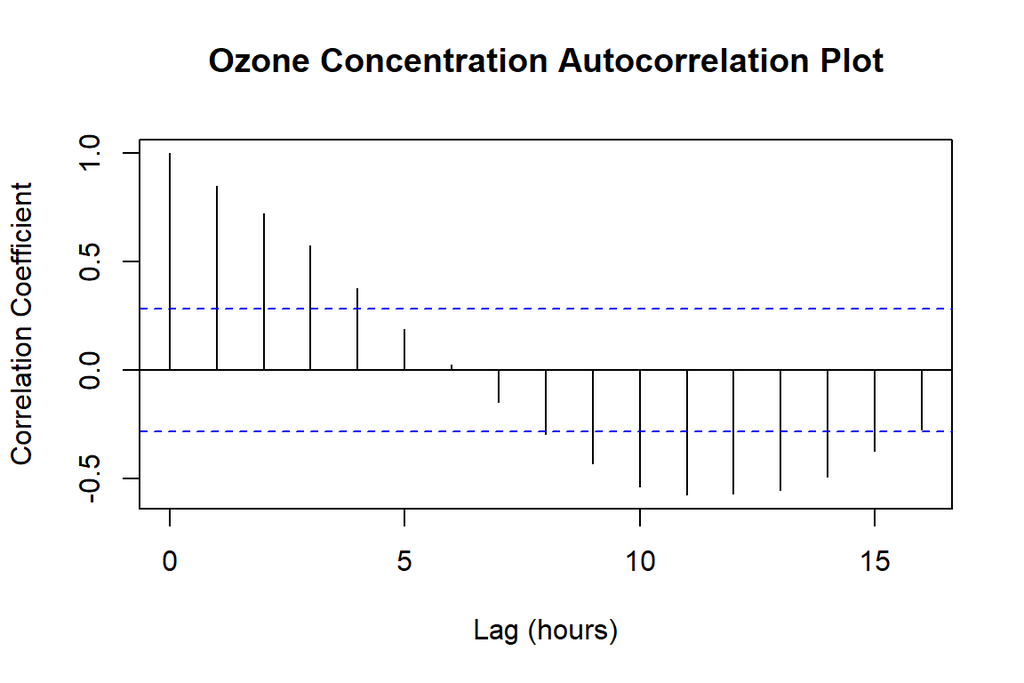

Define partial autocorrelation as it relates to ozone concentration measurement.

Partial auto correlation is when some of the data is influenced by the previous data point.

# Appendix

```r
# set global options for figures, code, warnings, and messages
knitr::opts_chunk$set(fig.width = 6, fig.height = 4, fig.path = "../figs/",
                      echo = FALSE, warning = FALSE, message = FALSE)
# load packages
library("tidyverse")
library("readr")
library("dplyr")
library("magrittr")
library("ggplot2")
# ozone: import, select, drop missing observations, rename
ozone_data <- tibble(readr::read_csv(file ="../data/ftc_o3.csv"))%>%
dplyr::select(sample_measurement, datetime)%>%
dplyr::rename(ozone_ppm = sample_measurement)%>%
filter(!is.na(ozone_ppm) & !is.na(datetime))
# examine dataframe object
head(ozone_data,n=20)
# calculate quantiles of ozone concentration
quantile(ozone_data$ozone_ppm, probs = seq(0, 1, 0.5))
# plot cumulative distribution of ozone concentration
ozone_data %>%
  ggplot2::ggplot(mapping = aes(x = ozone_ppm)) +
  geom_step(stat = "ecdf") + # "empirical cumulative distribution function"
  labs(x = "ozone_ppm", y = "Cumulative Fraction") +
  scale_y_continuous(limits = c(-0.05, 1.03),
                     expand = c(0,0),
                     breaks = seq(from = 0,
                                  to = 1,
                                  by = 0.1)) +
  scale_x_continuous(
                     minor_breaks = seq(from = 0,
                                        to = 1,
                                        by = 0.01))+
  geom_segment(data = data.frame(x = quantile(ozone_data$ozone_ppm),
                                 y = rep.int(-.05, 5),
                                 xend = quantile(ozone_data$ozone_ppm),
                                 yend = seq(from = 0, to = 1, by = 0.25)),
               aes(x = x, y = y, xend = xend, yend = yend),
               color = "green",
               linetype = "dashed") +
  theme_bw()
# create histogram of ozone concentration
histogram <- ggplot(ozone_data) +
  geom_histogram(aes(x = ozone_ppm),
                bins = 50,
                color = "white",
                fill = 'green') +
  xlim(min(ozone_data$ozone_ppm),
       max(ozone_data$ozone_ppm)) +
  labs(x = "Ozone Concentration (ppm)",
       y = "Measurements",
       title = "Ozone Concentration Histogram",
       subtitle = "Fort Collins, CO") +
theme_minimal()

print(histogram)
# create ozone boxplot
boxplot <- ggplot(data = ozone_data,
       aes(x = '',
           y = ozone_ppm),
       color = "green",
       fill = 'green')+
  geom_boxplot(width = 0.1) +
  labs(x = '',
       y = "Ozone Concentration (PPM)",
       title = "Ozone Concentration Boxplot") +
  theme_minimal()
print(boxplot)
# create subset of data with only one day to examine daily pattern
# I did not ask you to code this because we have not discussed dates or stringr
# You need to uncomment the below three lines and run it; check object names
ozone_day <- ozone_data %>%
 dplyr::filter(stringr::str_detect(string = datetime,
                                    pattern = "2019-07-04"))
# create autocorrelation plot with ozone_day df

stats::acf(ozone_day$ozone_ppm,
           main = "Ozone Concentration Autocorrelation Plot",
           xlab = "Lag (hours)",
           ylab = "Correlation Coefficient")

# create partial autocorrelation plot
```